# Data Analysis on Worldwide Child Malnutrition

Jing Cao, Jingjing Dong, Xinyue Sun, Erica Zhang

11/14/2022

#### Overall Summarization

```
## $num_observations
## [1] 12
##
## $num_variables
## [1] 8
##
## $beginning_year
## [1] 2010
##
## $end_year
## [1] 2020
##
## $max_stunting_prev_num_region
## # A tibble: 1 × 2
## # Groups:   region [1]
##   region                 stunting_prevalence_percentage
##   <chr>                                           <dbl>
## 1 South-East Asia Region                           41.6
##
## $max_overweight_prev_num_region
## # A tibble: 1 × 2
## # Groups:   region [1]
##   region        overweight_prevalence_percentage
##   <chr>                                    <dbl>
## 1 Europe Region                              9.8
##
## $max_wasting_prev_num_region
## # A tibble: 1 × 2
## # Groups:   region [1]
##   region                 wasting_prevalence_percentage
##   <chr>                                          <dbl>
## 1 South-East Asia Region                          14.5
```

The project reports current relevant information on child malnutrition from 2010 to 2020. To have a more comprehensive analysis, we have 12 observations in total in exploring child malnutrition situations among different regions and how it can be affected by different household incomes. The 8 variables we have for the report are prevalence and number of three different types of malnutrition along with the influential factor region and year. South-East Asia Region has the highest prevalence of stunting, 41.6%. Europe Region has the highest prevalence of overweight, and the number is 9.8%. South-East Asia Region also has the highest prevalence of wasting, which is 14.5%.

#### Demonstration of table containing aggregate data

```
## # A tibble: 132 × 8
## # Groups:   region [12]
##    region                   year stunt…¹ stunt…² overw…³ overw…⁴ wasti…⁵ wasti…⁶
##    <chr>                   <dbl>   <dbl>   <dbl>   <dbl>   <dbl>   <dbl>   <dbl>
##  1 Global                   2010   180.     27.7    36.4     5.6      NA      NA
##  2 African Region           2010    53.6    37.4     6.1     4.3      NA      NA
##  3 Region of the Americas   2010     7.8    10.3     5.8     7.6      NA      NA
##  4 South-East Asia Region   2010    75.9    41.6     5.8     3.2      NA      NA
##  5 Eastern Mediterranean …  2010    23.4    31.4     5.8     7.8      NA      NA
##  6 Europe Region            2010     4.1     7.6     5.4     9.8      NA      NA
##  7 Western Pacific Region   2010    15.4    12.9     7.4     6.2      NA      NA
##  8 Low income               2010    36      41.4     3.6     4.1      NA      NA
##  9 Middle Income            2010   141      28.6    27.9     5.7      NA      NA
## 10 Lower-middle income      2010   123.     37.6    14.3     4.4      NA      NA
## # … with 122 more rows, and abbreviated variable names
## #   ¹stunting_number_millions, ²stunting_prevalence_percentage,
## #   ³overweight_number_millions, ⁴overweight_prevalence_percentage,
## #   ⁵wasting_number_millions, ⁶wasting_prevalence_percentage
```

This table contains all data on child malnutrition from 2010 to 2020 across various regions provided by UNICEF. Since we want to explore the pattern of child malnutrition, we can access concrete population and prevalence of malnourished kids from this aggregate data. The purpose of this table is not only to allow us to conveniently filter the data for further analysis, but also to enable our audience to understand the scope of this project. In detail, this table reveals annual numbers and percentages of child stunting, overweight, and wasting in each region. We can roughly learn the trend and distribution of child malnutrition from this table. It is noticed that data on child wasting were missing in earlier years. Using `group_by` on the feature `region`, it can be found that there are 12 dimensions, in which one for global, six for WHO regions, and five for World Bank income groups. These dimensions facilitate our analysis on child malnutrition by region and by income.

#### Demonstration of plot one

[figure not shown]

#### Demonstration of plot two

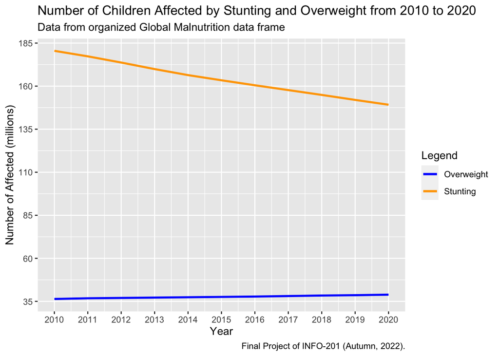

This run chart shows number of millions of children affected by stunting and overweight globally from 2010 to 2020. All children suffered from those two malnutrition symptoms are aged under five. It is clearly reflected that many more children are affected by stunting over recent ten years. The number of overweight children is between 35 to 40 million and is increasing slowly. The number of stunting children had reached 180.5 million in year 2010, but the negative slope also shows a positive trend that there are fewer children are stunting. This visualization only shows two symptoms of malnutrition, and the reason of excluding wasting is that we only have data of wasting in 2020. Since wasting has not been concerned by the public until recent years, the information we can have is rare. More detailed information about wasting is shown in plot 1 and in aggregated table.

#### Demonstration of plot three

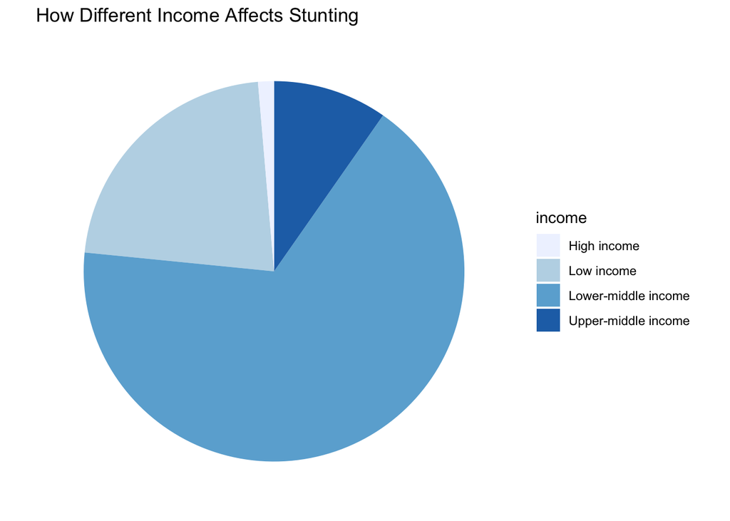

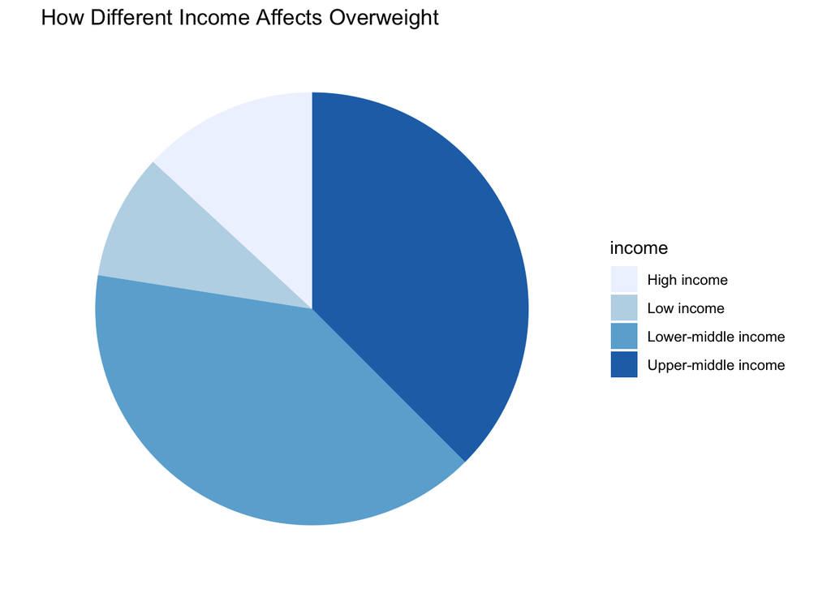

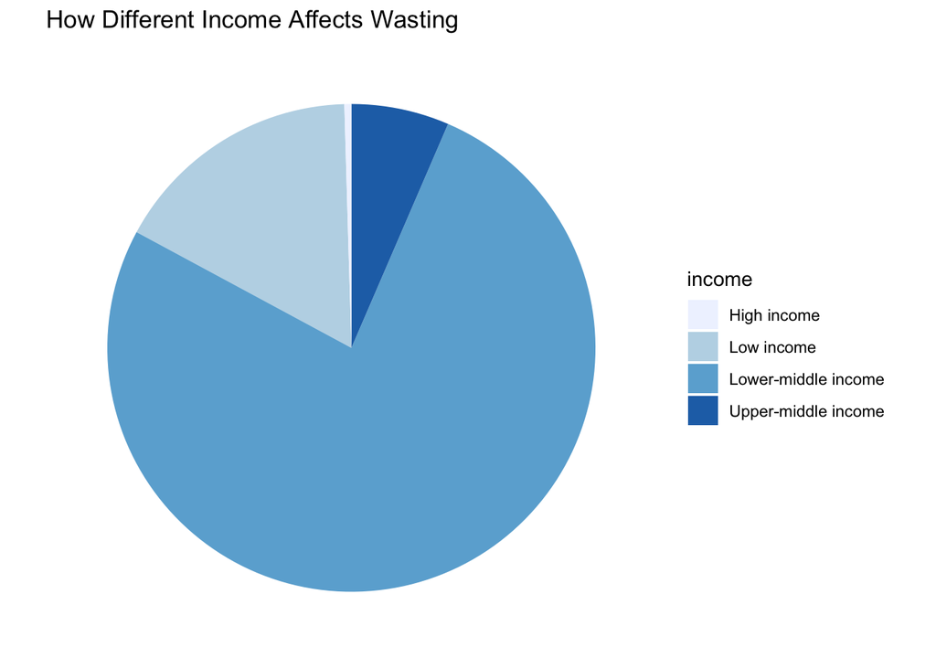